# Homework: HbA1c Control Trends — Clinics B & D, and a Simple ITS v2

## Setup

```r
library(readr)
library(dplyr)
library(lubridate)
library(qicharts2)
```

## Load the data

```r
encounters <- read_csv("data/encounters.csv")
labs <- read_csv("data/labs.csv")
lookup <- read_csv("data/provider_lookup.csv")
```

Same three files as class. This time you’re finishing Clinics B and D, which have two additional problems A and C didn’t.

## Part 1: Build the measure

### Parse dates (same as class)

```r
encounters$encounter_date <- parse_date_time(encounters$encounter_date, orders = c("ymd", "mdy"))

labs$result_date <- parse_date_time(labs$result_date,orders = c("ymd", "mdy"))

sum(is.na(encounters$encounter_date)) == 0
```

```
[1] TRUE
```

```r
sum(is.na(labs$result_date)) == 0
```

```
[1] TRUE
```

```r
# TODO: reuse your mixed-date parser from class on encounter_date and
# result_date.
```

### Task 1: standardize the join key, then join

```r
# TODO: first, try the plain join from class:

# and check how many rows come back with a missing clinic_id. Then look
# at a sample of the unmatched provider_id values -- what's inconsistent
# about them relative to provider_lookup.csv?
encounters$provider_id <- toupper(trimws(encounters$provider_id))
lookup$provider_id <- toupper(trimws(lookup$provider_id))

encounters <- encounters %>% left_join(lookup, by = "provider_id")

sum(is.na(encounters$clinic_id))
```

```
[1] 0
```

```r
# TODO: create a standardized version of provider_id on BOTH tables
# (case + whitespace), then join on the standardized version. Confirm
# zero unmatched rows afterward.
```

### Build the denominator

```r
# TODO: same logic as class,
# filter to Clinic B and Clinic D.
# set dates to month level
# reduce to unique patients per clinic per month rows
# count the number for rows
denominator <- encounters %>%
  filter(clinic_id %in% c("Clinic B", "Clinic D")) %>%
  mutate(month = floor_date(encounter_date, "month")) %>%
  distinct(clinic_id, month, patient_id) %>%
  count(clinic_id, month, name = "denominator")
```

### Clean the labs and handle Task 2: implausible values

```r
# TODO: filter to test_name == "HbA1c", convert result_value to numeric,
# drop non-numeric/missing entries, remove exact duplicates -- same logic as
# class.
labs <- labs %>%
  filter(test_name == "HbA1c") %>%
  mutate(result_value = as.numeric(result_value)) %>%
  filter(!is.na(result_value)) %>%
  distinct()
labs
```

```
# A tibble: 4,206 × 5
   row_id  patient_id result_date         test_name result_value
   <chr>   <chr>      <dttm>              <chr>            <dbl>
 1 L000002 B-P0017    2023-08-10 00:00:00 HbA1c              7.7
 2 L000004 D-P0035    2023-11-01 00:00:00 HbA1c              9.2
 3 L000006 D-P0012    2024-02-04 00:00:00 HbA1c             10.6
 4 L000007 B-P0015    2024-05-09 00:00:00 HbA1c              6.4
 5 L000008 D-P0041    2025-07-10 00:00:00 HbA1c              5.8
 6 L000009 B-P0036    2025-03-25 00:00:00 HbA1c             10.6
 7 L000011 A-P0021    2023-11-13 00:00:00 HbA1c              7.1
 8 L000012 A-P0018    2023-09-11 00:00:00 HbA1c              7.3
 9 L000013 A-P0018    2023-04-12 00:00:00 HbA1c              6.7
10 L000014 B-P0062    2023-02-14 00:00:00 HbA1c              5.9
# ℹ 4,196 more rows
```

```r
# TODO (Task 2): before computing the numerator, add a plausible-range
# filter on the numeric value (a reasonable range for this exercise is
# roughly 4-15). Report how many rows this excludes. Also convert dates to month.
sum(labs$result_value < 4 | labs$result_value > 15)
```

```
[1] 18
```

```r
labs <- labs %>%
  filter(result_value >= 4, result_value <= 15) %>%
  mutate(month = floor_date(result_date, "month"))
```

### Build the numerator and assemble the measure table

```r
# TODO: same join-back-to-clinic-month logic as class
# First, identify unique patient visits in a month.
patients <- encounters %>%
  filter(clinic_id %in% c("Clinic B", "Clinic D")) %>%
  mutate(month = floor_date(encounter_date, "month")) %>%
  distinct(clinic_id, month, patient_id)

patients
```

```
# A tibble: 2,386 × 3
   clinic_id month               patient_id
   <chr>     <dttm>              <chr>
 1 Clinic D  2023-09-01 00:00:00 D-P0034
 2 Clinic B  2023-08-01 00:00:00 B-P0017
 3 Clinic B  2025-04-01 00:00:00 B-P0062
 4 Clinic D  2025-03-01 00:00:00 D-P0009
 5 Clinic B  2025-11-01 00:00:00 B-P0013
 6 Clinic D  2024-09-01 00:00:00 D-P0007
 7 Clinic B  2023-01-01 00:00:00 B-P0030
 8 Clinic D  2023-07-01 00:00:00 D-P0026
 9 Clinic B  2024-09-01 00:00:00 B-P0068
10 Clinic D  2025-06-01 00:00:00 D-P0033
# ℹ 2,376 more rows
```

```r
# Finish generating a numerator - # of patients with controlled values (under 8)
# Filter to controlled lab values, join to the patient-by month file above.
# Identify unique patients per month per clinic
# Count how many patients per month had controlled lab values. This is the numerator.
#
numerator <- labs %>%
  filter(result_value < 8) %>%
  inner_join(patients, by = c("patient_id", "month")) %>%
  distinct(clinic_id, month, patient_id) %>%
  count(clinic_id, month, name = "numerator")

numerator
```

```
# A tibble: 72 × 3
   clinic_id month               numerator
   <chr>     <dttm>                  <int>
 1 Clinic B  2023-01-01 00:00:00        15
 2 Clinic B  2023-02-01 00:00:00        19
 3 Clinic B  2023-03-01 00:00:00        19
 4 Clinic B  2023-04-01 00:00:00        16
 5 Clinic B  2023-05-01 00:00:00        17
 6 Clinic B  2023-06-01 00:00:00        19
 7 Clinic B  2023-07-01 00:00:00        17
 8 Clinic B  2023-08-01 00:00:00        17
 9 Clinic B  2023-09-01 00:00:00        20
10 Clinic B  2023-10-01 00:00:00        15
# ℹ 62 more rows
```

```r
# Join numerator and denominator together

measure <- denominator %>%
  left_join(numerator, by = c("clinic_id", "month")) %>%
  mutate(
    numerator = ifelse(is.na(numerator), 0, numerator),
    rate = numerator / denominator
  )

measure
```

```
# A tibble: 72 × 5
   clinic_id month               denominator numerator  rate
   <chr>     <dttm>                    <int>     <int> <dbl>
 1 Clinic B  2023-01-01 00:00:00          30        15 0.5
 2 Clinic B  2023-02-01 00:00:00          41        19 0.463
 3 Clinic B  2023-03-01 00:00:00          37        19 0.514
 4 Clinic B  2023-04-01 00:00:00          31        16 0.516
 5 Clinic B  2023-05-01 00:00:00          33        17 0.515
 6 Clinic B  2023-06-01 00:00:00          40        19 0.475
 7 Clinic B  2023-07-01 00:00:00          40        17 0.425
 8 Clinic B  2023-08-01 00:00:00          34        17 0.5
 9 Clinic B  2023-09-01 00:00:00          39        20 0.513
10 Clinic B  2023-10-01 00:00:00          35        15 0.429
# ℹ 62 more rows
```

## Part 2: Control charts

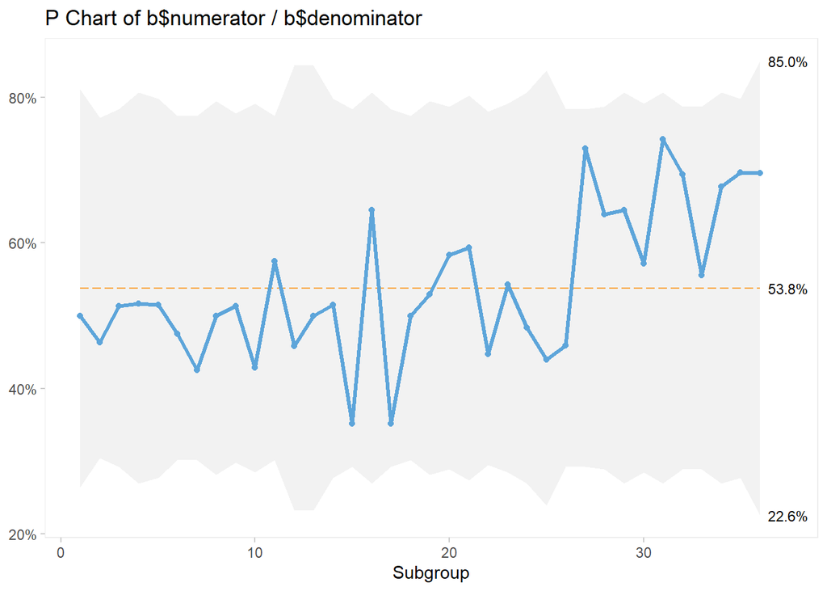

```r
b <- measure %>%
  filter(clinic_id == "Clinic B")

chart_b <- qic(
  x = b$numerator,
  n = b$denominator,
  chart = "p"
)

print(chart_b)
```

```r
# TODO: qic() with chart = "p" for Clinic B. Store the result.
```

*Clinic B interpretation:*

> [3-5 sentences: signal present? sigma or runs? plausible cause? next step?] signal is run as center line is at 53.8% and the data points the last 10 months are above center line and before months fluctuate around the center line. **One-line status:** [Clinic B shows a positive signal with a run above the center line, indicating improvement in HbA1c control.]

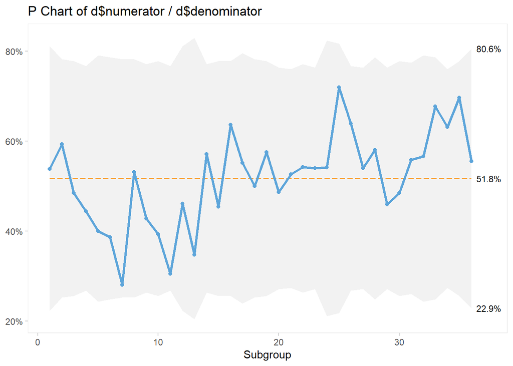

```r
d <- measure %>%
  filter(clinic_id == "Clinic D")

chart_d <- qic(
  x = d$numerator,
  n = d$denominator,
  chart = "p"
)
print(chart_d)
```

```r
# TODO: qic() with chart = "p" for Clinic D.
```

## Part 3: A simple interrupted time series (Clinic B)

```r
its_b <- measure %>%
  filter(clinic_id == "Clinic B") %>%
  arrange(month) %>%
  mutate(
    rate = numerator / denominator,
    t = 1:n(),
    post = ifelse(month >= as.Date("2025-03-01"), 1, 0),
    t_post = ifelse(post == 1, t - sum(post == 0), 0)
  )

its_b
```

```
# A tibble: 36 × 8
   clinic_id month               denominator numerator  rate     t  post t_post
   <chr>     <dttm>                    <int>     <int> <dbl> <int> <dbl>  <dbl>
 1 Clinic B  2023-01-01 00:00:00          30        15 0.5       1     0      0
 2 Clinic B  2023-02-01 00:00:00          41        19 0.463     2     0      0
 3 Clinic B  2023-03-01 00:00:00          37        19 0.514     3     0      0
 4 Clinic B  2023-04-01 00:00:00          31        16 0.516     4     0      0
 5 Clinic B  2023-05-01 00:00:00          33        17 0.515     5     0      0
 6 Clinic B  2023-06-01 00:00:00          40        19 0.475     6     0      0
 7 Clinic B  2023-07-01 00:00:00          40        17 0.425     7     0      0
 8 Clinic B  2023-08-01 00:00:00          34        17 0.5       8     0      0
 9 Clinic B  2023-09-01 00:00:00          39        20 0.513     9     0      0
10 Clinic B  2023-10-01 00:00:00          35        15 0.429    10     0      0
# ℹ 26 more rows
```

```r
# TODO: build a data frame for Clinic B with:
#   - rate = numerator / denominator
#   - t = a simple 1, 2, 3, ... month counter
#   - post = 0/1 indicator for month >= 2025-03-01
#   - t_post = post * (a counter that starts at 1 on the intervention
#     month and counts up from there, 0 before it)
```

```r
# TODO: fit lm(rate ~ t + post, data = ...) and look at
its_model <- lm(rate ~ t + post + t_post, data = its_b)

summary(its_model)
```

```
Call:
lm(formula = rate ~ t + post + t_post, data = its_b)

Residuals:
      Min        1Q    Median        3Q       Max
-0.142834 -0.035194  0.008948  0.028852  0.151227

Coefficients:
             Estimate Std. Error t value Pr(>|t|)
(Intercept) 0.4899238  0.0273379  17.921  < 2e-16 ***
t           0.0002507  0.0017702   0.142  0.88828
post        0.1627426  0.0529581   3.073  0.00431 **
t_post      0.0007557  0.0076605   0.099  0.92203
---
Signif. codes:  0 '***' 0.001 '**' 0.01 '*' 0.05 '.' 0.1 ' ' 1

Residual standard error: 0.0677 on 32 degrees of freedom
Multiple R-squared:  0.5915,    Adjusted R-squared:  0.5532
F-statistic: 15.45 on 3 and 32 DF,  p-value: 2.176e-06
```

```r
# summary(). Extract/interpret the post and t_post coefficients.
```

*Interpretation:*

> [What does the `post` coefficient mean, and is it significant? What does `t_post` mean, and is it significant? Does this agree with what the control chart’s signal already told you? Explain, in your own words, what each method is actually testing and why they might (or might not) agree.]

post=tells us how observation is after intervention,it is significant t_post tells us how the trend is after intervention, it is not significant. The control chart shows a positive signal with a run above the center line, indicating improvement in HbA1c control.

```r
summary(its_model)
```

```
Call:
lm(formula = rate ~ t + post + t_post, data = its_b)

Residuals:
      Min        1Q    Median        3Q       Max
-0.142834 -0.035194  0.008948  0.028852  0.151227

Coefficients:
             Estimate Std. Error t value Pr(>|t|)
(Intercept) 0.4899238  0.0273379  17.921  < 2e-16 ***
t           0.0002507  0.0017702   0.142  0.88828
post        0.1627426  0.0529581   3.073  0.00431 **
t_post      0.0007557  0.0076605   0.099  0.92203
---
Signif. codes:  0 '***' 0.001 '**' 0.01 '*' 0.05 '.' 0.1 ' ' 1

Residual standard error: 0.0677 on 32 degrees of freedom
Multiple R-squared:  0.5915,    Adjusted R-squared:  0.5532
F-statistic: 15.45 on 3 and 32 DF,  p-value: 2.176e-06
```